# Assignment 2

Ana Zhibaj

## Loading data

```r
library(ggplot2)
library(sf)
library(rnaturalearth)
library(tidyverse)
library(ggspatial)
library(cartogram)
library(ggthemes)
library(cowplot)
library(googleway)
library(ggrepel)
library(rnaturalearthdata)
library(extrafont)
library(extrafontdb)
library(readr)
```

### World map

Let’s start by drawing a quick map of the world.

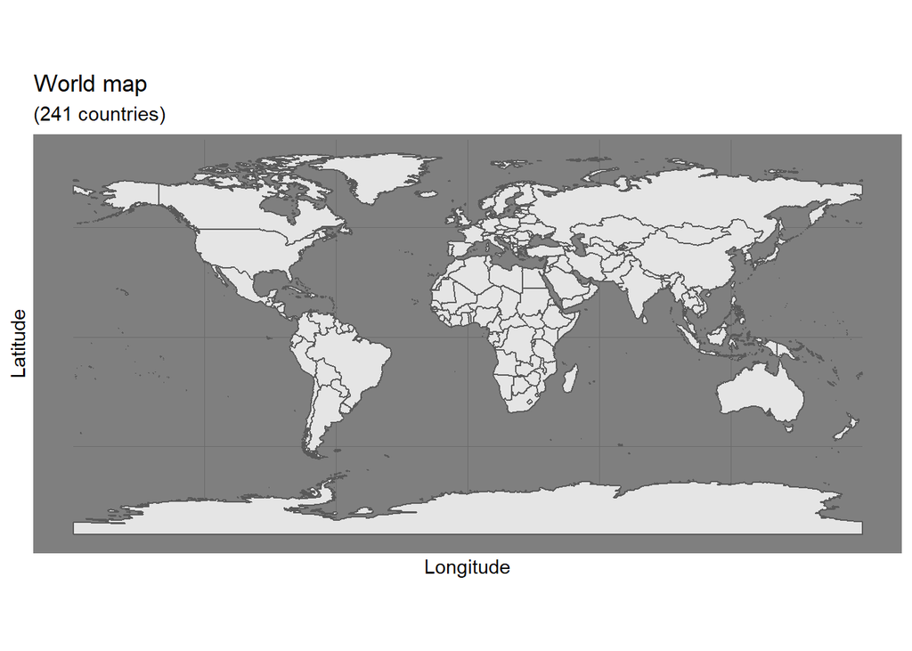

```r
world <- ne_countries(scale = 50, returnclass = "sf")
world_map <- ggplot(world) +
  geom_sf() +
  xlab("Longitude") + ylab("Latitude") +
    ggtitle("World map", subtitle = paste0("(", length(unique(world$name)), " countries)")) +
  theme_dark()
world_map
```

### Countries in Europe

Now let’s do a map of just countries in Europe.

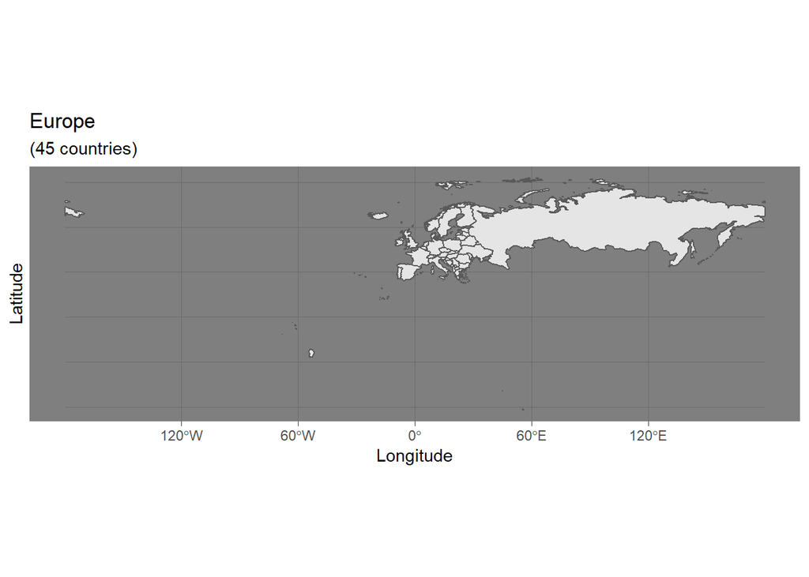

```r
eu_countries <- world %>%
  filter(continent == "Europe")
eu_map <- ggplot(eu_countries) +
  geom_sf() +
  xlab("Longitude") + ylab("Latitude") +
    ggtitle("Europe", subtitle = paste0("(", length(unique(eu_countries$sovereignt)), " countries)")) +
  theme_dark()
eu_map
```

## Reprojecting map data

I chose three projection systems: Bonne projection is an equal area map projection, Bipolar Conic projection (two conic projections used to create new maps of North and South America) and the Icosahedral Snyder Equal area (low scale and angular distortion, but there are visible interruptions).

```r
bonne <- "+proj=bonne +lat_1=10"
bipolar_conic <- "+proj=bipc +ns"
icosahedral_snyder <- "+proj=isea"
```

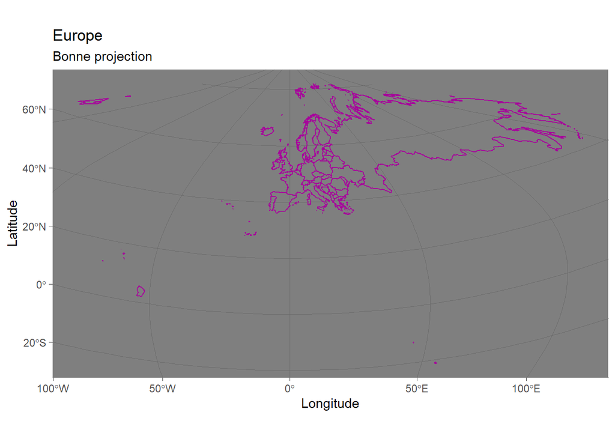

```r
ggplot(eu_countries) +
geom_sf( fill = NA, color = "#A6039B") + #blade runner 2049
  xlab("Longitude") + ylab("Latitude") +
    ggtitle("Europe", subtitle = paste0("Bonne projection")) +
  coord_sf(crs = bonne) +
  theme_dark()
```

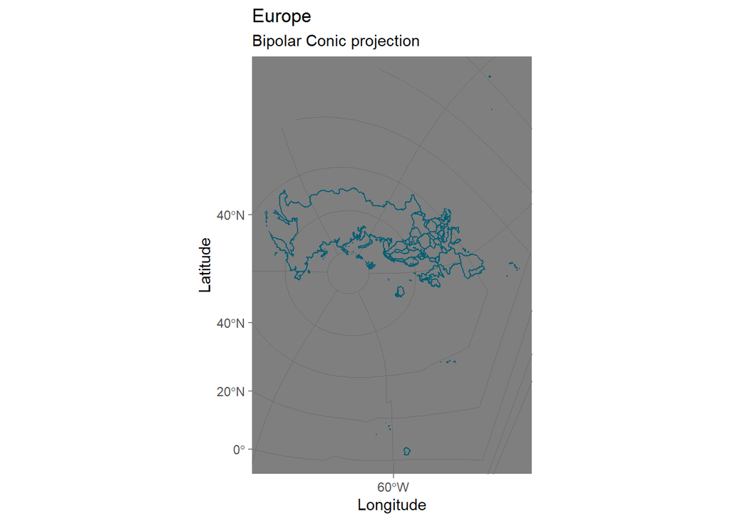

```r
ggplot(eu_countries) +
  geom_sf( fill = NA, color = "#025E73") +
  xlab("Longitude") + ylab("Latitude") +
    ggtitle("Europe", subtitle = paste0("Bipolar Conic projection")) +
  coord_sf(crs = bipolar_conic) +
  theme_dark()
```

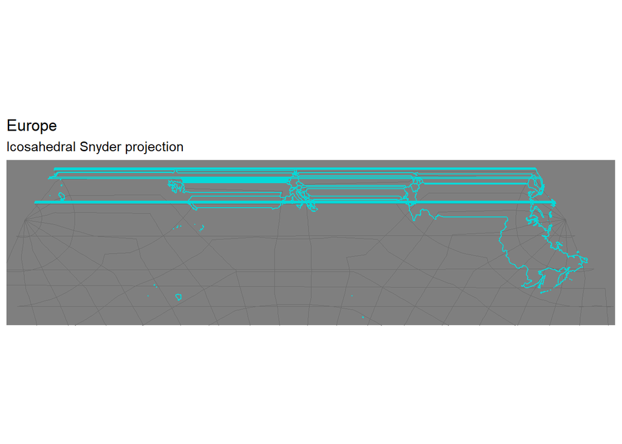

```r
ggplot(eu_countries) +
  geom_sf( fill = NA, color = "#04D9D9") +
    ggtitle("Europe", subtitle = paste0("Icosahedral Snyder projection")) +
  coord_sf(crs = icosahedral_snyder) +
  theme_dark()
```

## Transforming coordinate systems

I’ll transform my data using ‘st_transform()’ with the Bonne projection.

```r
europe_transformed <- eu_countries %>% #the name doesnt refer to the accession in the EU, just short for europe sigh
  st_transform(crs = bonne)
```

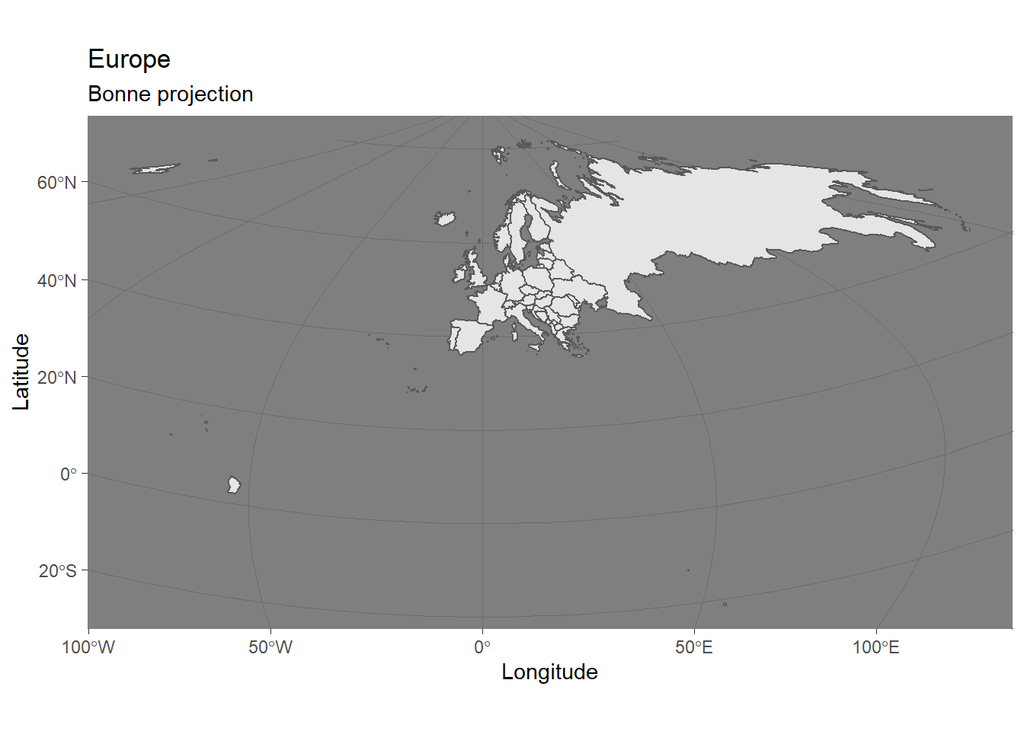

```r
ggplot(europe_transformed) +
  geom_sf() +
  xlab("Longitude") + ylab("Latitude") +
    ggtitle("Europe", subtitle = paste0("Bonne projection")) +
  theme_dark()
```

```r
europe_cropped <- st_crop(europe_transformed, xmin = -2000000, xmax = 4500000,
                                    ymin = 3000000, ymax = 7300000)
```

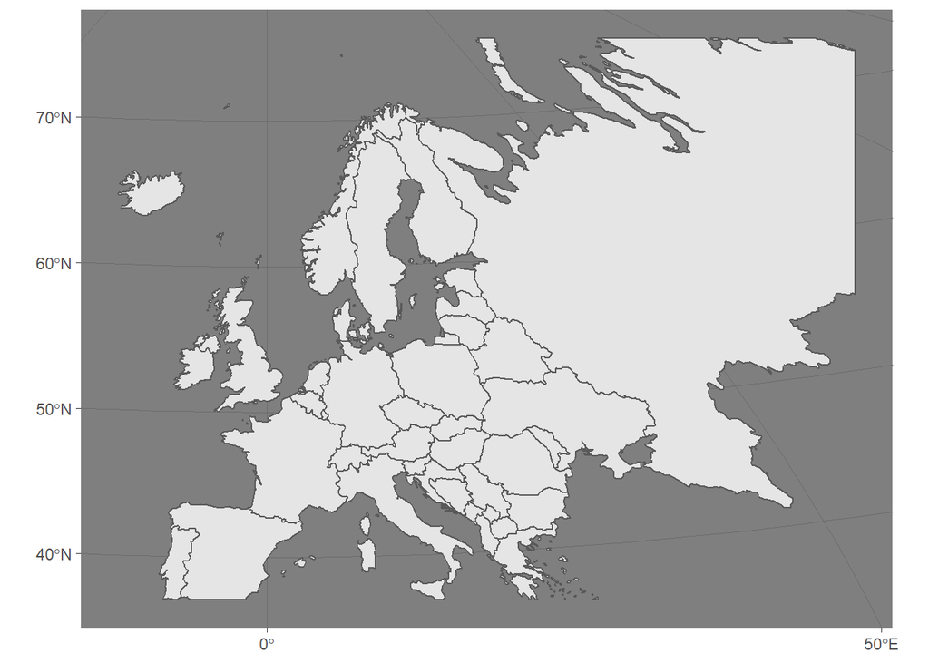

```r
ggplot() + geom_sf(data = europe_cropped) + theme_dark()
```

## Chloropleth map

The rnaturalearth package includes GDP and population estimates for countries. I have used these variables to produce the following maps.

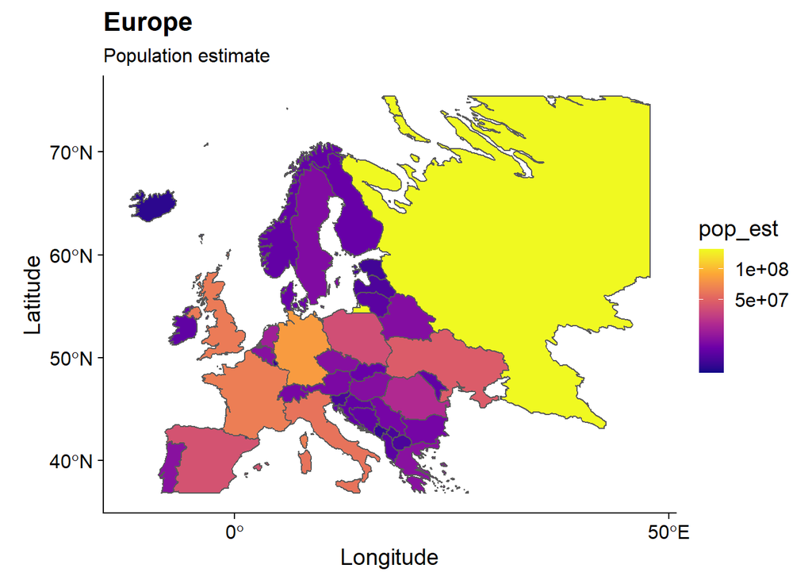

```r
ggplot(data = europe_cropped) +
  geom_sf(aes(fill = pop_est)) +
  xlab("Longitude") + ylab("Latitude") +
    ggtitle("Europe", subtitle = paste0("Population estimate")) +
    scale_fill_viridis_c(option = "plasma", trans = "sqrt") +
  theme_cowplot()
```

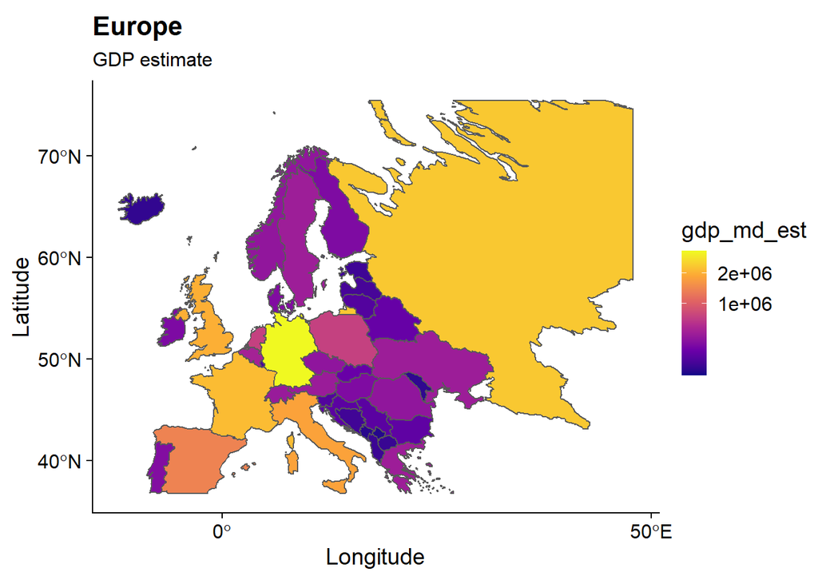

```r
ggplot(data = europe_cropped) +
    geom_sf(aes(fill = gdp_md_est)) +
  xlab("Longitude") + ylab("Latitude") +
    ggtitle("Europe", subtitle = paste0("GDP estimate")) +
    scale_fill_viridis_c(option = "plasma", trans = "sqrt") +
  theme_cowplot()
```

## Cartograms

### Continuous cartogram

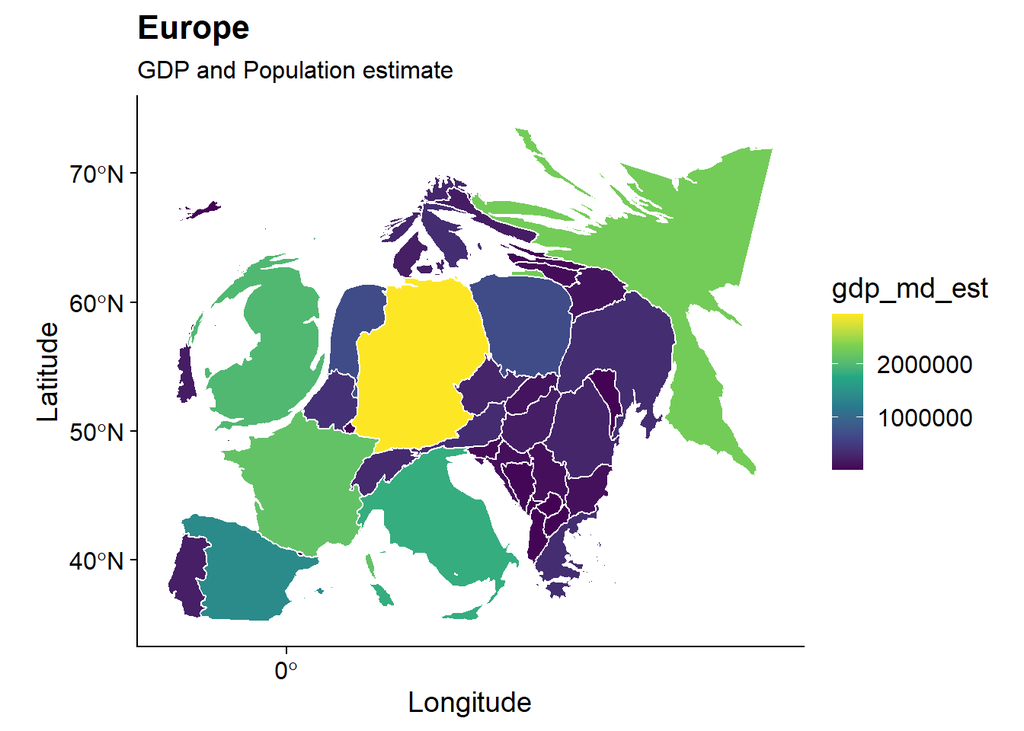

```r
options(scipen = 999)
europe_cartogram_cont <- europe_cropped %>%
 cartogram_cont("pop_est")
ggplot(europe_cartogram_cont, aes(fill = gdp_md_est)) +
  geom_sf( color = "white") +
  xlab("Longitude") + ylab("Latitude") +
    ggtitle("Europe", subtitle = paste0("GDP and Population estimate")) +
  scale_fill_viridis_c() +
  theme_cowplot()
```

### Non-continuous cartogram

A non-continuous cartogram will maintain the shapes and relative positions of states.

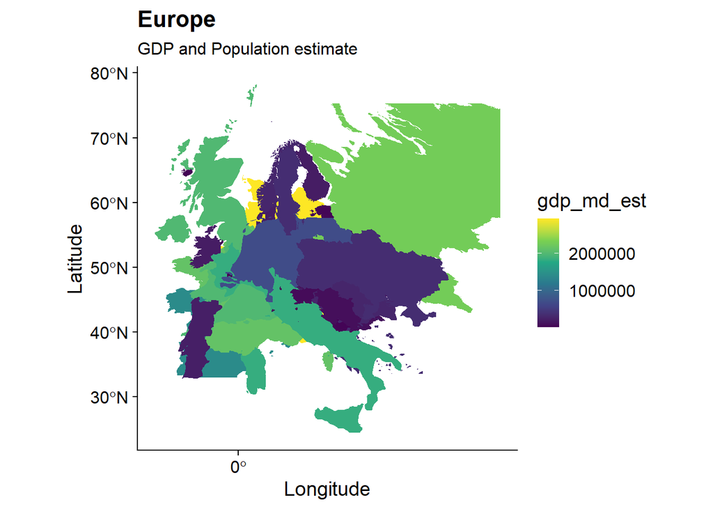

```r
europe_cartogram_ncont <- europe_cropped %>%
  cartogram_ncont("pop_est")
ggplot(europe_cartogram_ncont, aes(fill = gdp_md_est)) +
  geom_sf(color = NA) +
  xlab("Longitude") + ylab("Latitude") +
    ggtitle("Europe", subtitle = paste0("GDP and Population estimate")) +
  scale_fill_viridis_c() +
  theme_cowplot() +
  theme(legend.background = element_blank())
```

### Dorling cartogram

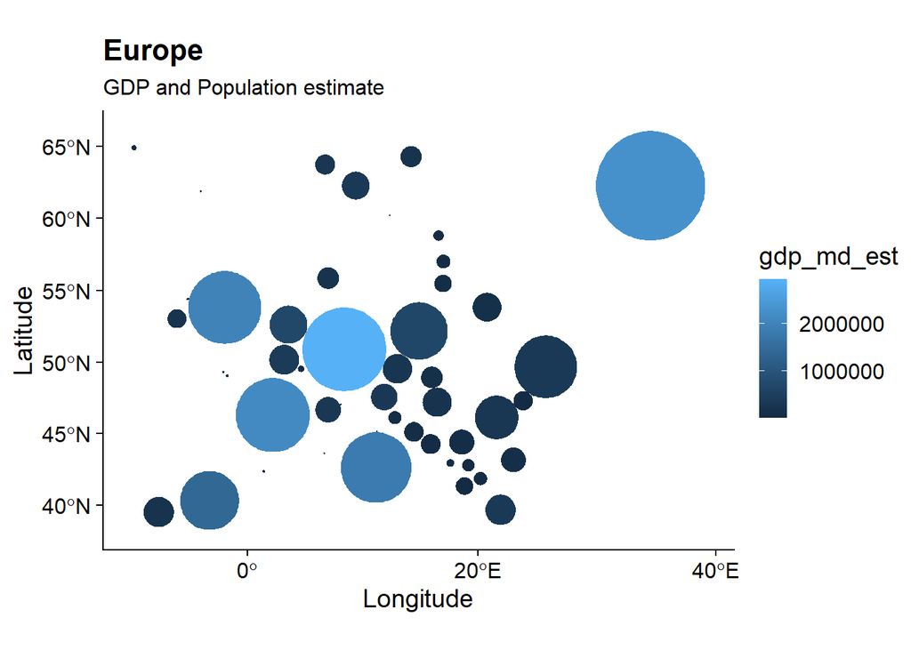

```r
europe_cartogram_dorling <- europe_cropped %>%
  cartogram_dorling("pop_est")
ggplot(europe_cartogram_dorling, aes(fill = gdp_md_est)) +
  geom_sf(color = NA) +
    xlab("Longitude") + ylab("Latitude") +
    ggtitle("Europe", subtitle = paste0("GDP and Population estimate")) +
  theme_cowplot() +
  theme(legend.background = element_blank())
```

### Proportional symbol map

```r
europe_centeroids <- europe_cropped %>%
  st_centroid()
```

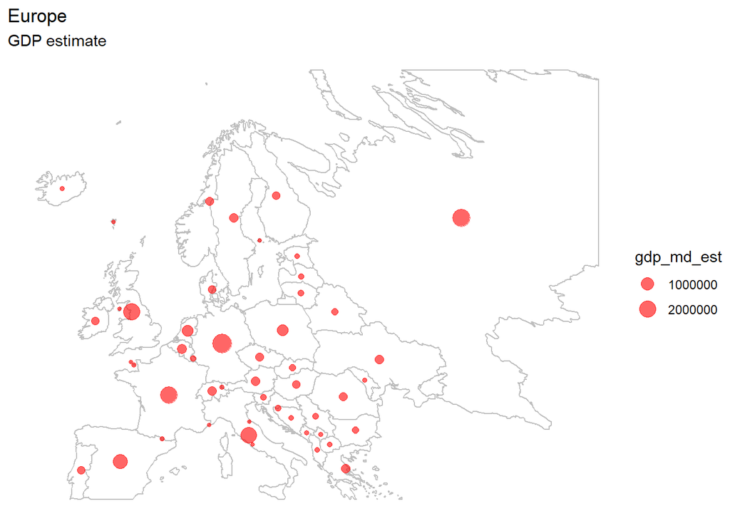

```r
ggplot(europe_cropped) +
  geom_sf(fill = NA, color = "gray") +
  geom_sf(data = europe_centeroids,
          aes(size = gdp_md_est),
          alpha = 0.6, color = "red") +
      xlab("Longitude") + ylab("Latitude") +
    ggtitle("Europe", subtitle = paste0("GDP estimate")) +
  theme_void()
```

# Balkans

Note: I initially looked into the Balkans region, but I hesitated to make it central to my assignment, considering the small number of countries and the lack of range.

## Balkans countries

This is a map of countries in the Balkans, as defined by Encyclopædia Britannica (retrieved September 20, 2020).

```
## Scale on map varies by more than 10%, scale bar may be inaccurate
```

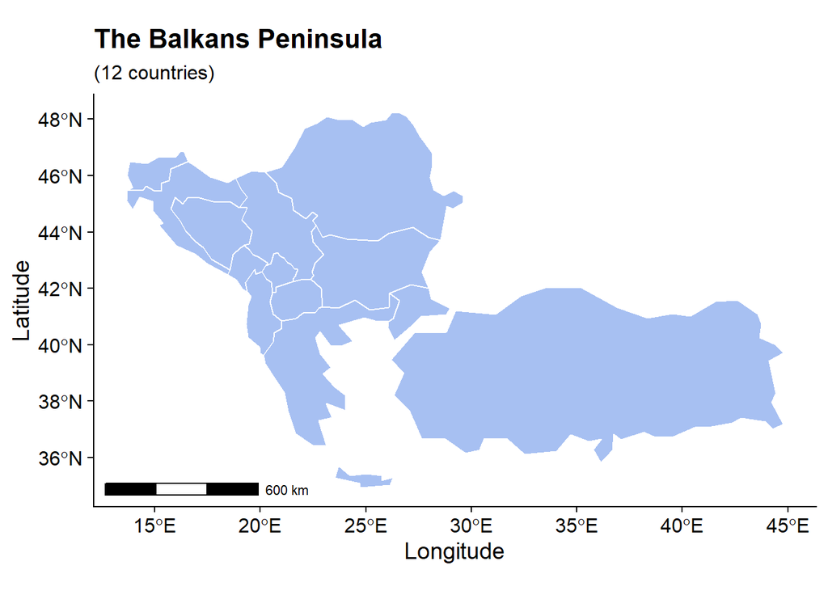

```r
alb <- ne_countries(sovereignt = c("Albania", "Bosnia and Herzegovina", "Bulgaria", "Croatia", "Kosovo", "Montenegro", "Macedonia", "Romania", "Republic of Serbia", "Slovenia", "Greece", "Turkey"), returnclass = "sf")
alb_map <- ggplot(alb) +
  geom_sf( fill = "#A7C0F2", color = "white") +
  xlab("Longitude") + ylab("Latitude") +
    ggtitle("The Balkans Peninsula", subtitle = paste0("(", length(unique(alb$sovereignt)), " countries)")) +
  theme_cowplot()
alb_map +
  annotation_scale()
```

## Reprojecting map data

I chose three projection systems: Balkans zone 6 that is relatively accurate (both in shape and distance), Bipolar Conic projection (two conic projections used to create new maps of North and South America) and the Icosahedral Snyder Equal area (low scale and angular distortion, but there are visible interruptions).

```r
balkans_zone_6 <- "+proj=tmerc +lat_0=0 +lon_0=18 +k=0.9999 +x_0=6500000 +y_0=0 +ellps=bessel +units=m +no_defs"
bipolar_conic <- "+proj=bipc +ns"
icosahedral_snyder <- "+proj=isea"
```

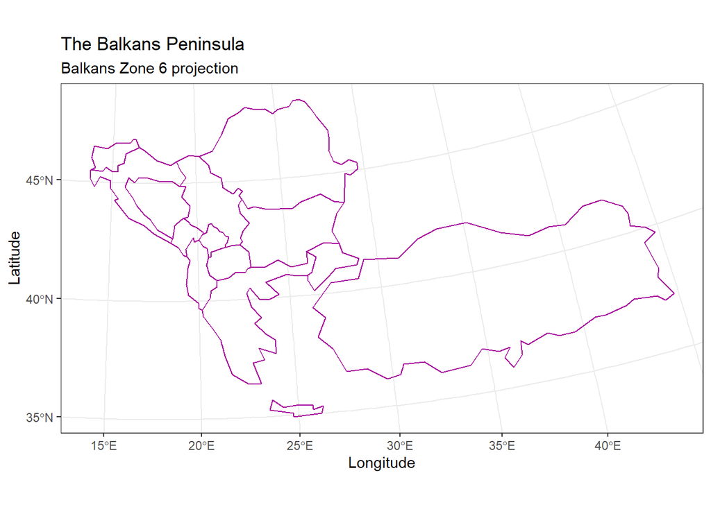

```r
ggplot(alb) +
  geom_sf( fill = NA, color = "#A6039B") + #blade runner 2049
  xlab("Longitude") + ylab("Latitude") +
    ggtitle("The Balkans Peninsula", subtitle = paste0("Balkans Zone 6 projection")) +
  coord_sf(crs = balkans_zone_6) +
  theme_bw()
```

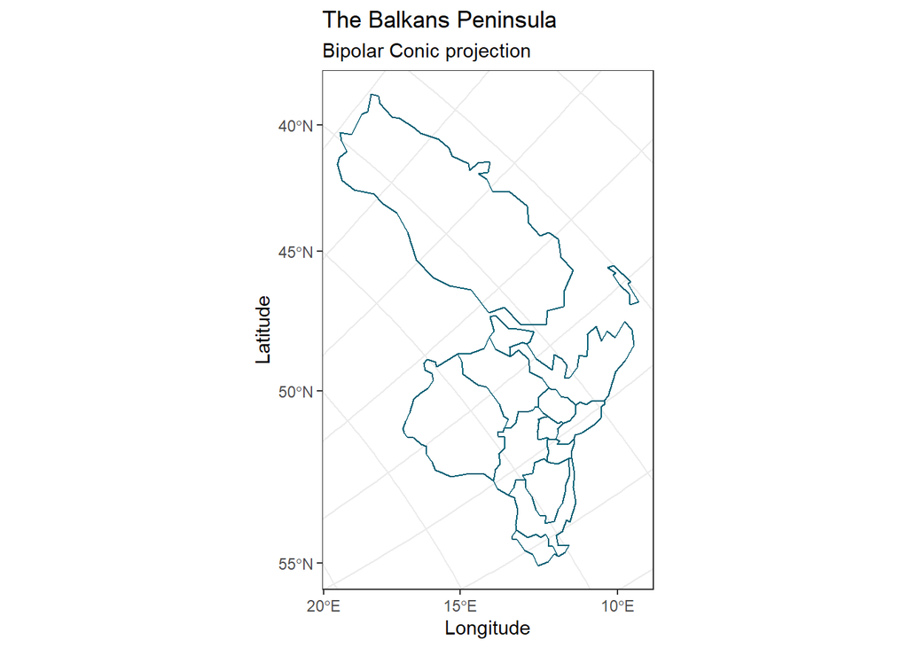

```r
ggplot(alb) +
  geom_sf( fill = NA, color = "#025E73") +
  xlab("Longitude") + ylab("Latitude") +
    ggtitle("The Balkans Peninsula", subtitle = paste0("Bipolar Conic projection")) +
  coord_sf(crs = bipolar_conic) +
  theme_bw()
```

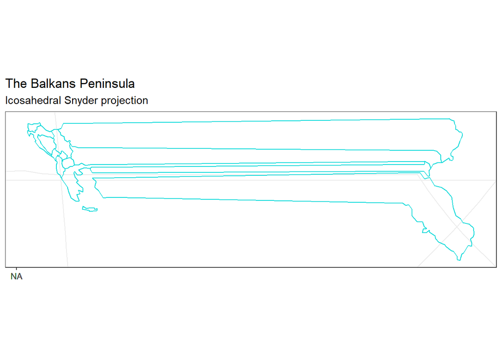

```r
ggplot(alb) +
  geom_sf( fill = NA, color = "#04D9D9") +
    ggtitle("The Balkans Peninsula", subtitle = paste0("Icosahedral Snyder projection")) +
  coord_sf(crs = icosahedral_snyder) +
  theme_bw()
```

## Transforming coordinate systems

I’ll transform my data using ‘st_transform()’ with the Balkans Zone 6 projection system.

```r
balkans_transformed <- alb %>%
  st_transform(crs = balkans_zone_6)
```

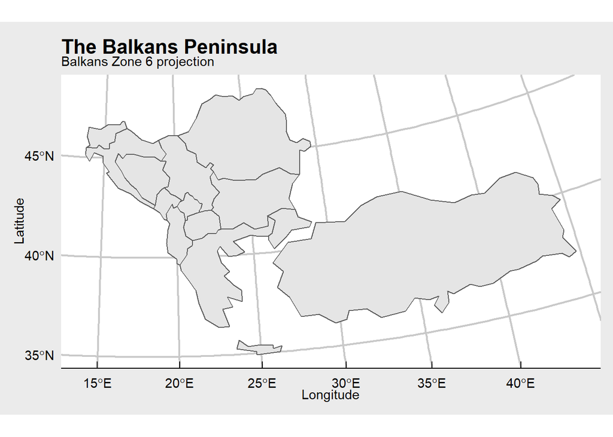

```r
ggplot(balkans_transformed) +
  geom_sf() +
  xlab("Longitude") + ylab("Latitude") +
    ggtitle("The Balkans Peninsula", subtitle = paste0("Balkans Zone 6 projection")) +
  theme_economist_white()
```

## Chloropleth map

The rnaturalearth package includes GDP and population estimates for countries. I have used these variables to produce the following maps.

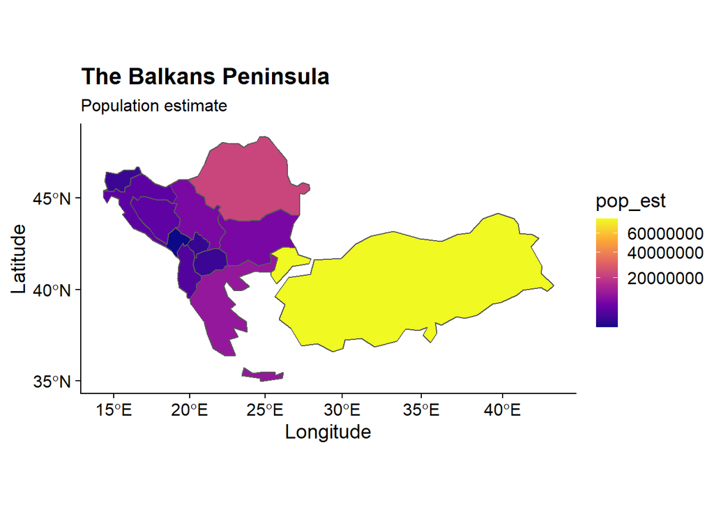

```r
ggplot(data = balkans_transformed) +
    geom_sf(aes(fill = pop_est)) +
  xlab("Longitude") + ylab("Latitude") +
    ggtitle("The Balkans Peninsula", subtitle = paste0("Population estimate")) +
    scale_fill_viridis_c(option = "plasma", trans = "sqrt") +
  theme_cowplot()
```

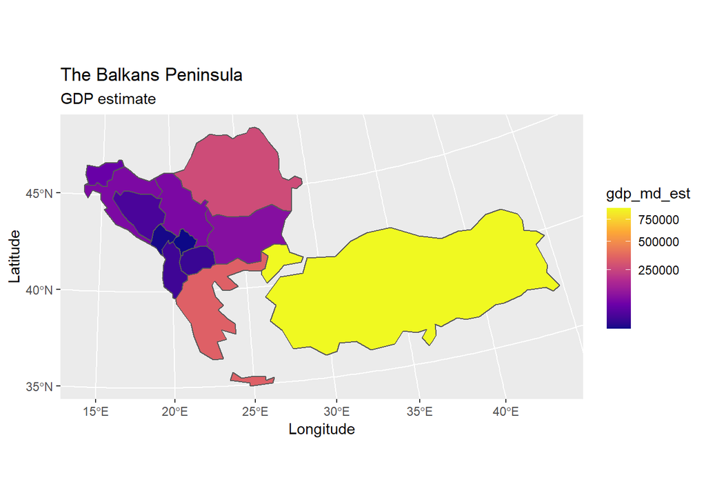

```r
ggplot(data = balkans_transformed) +
    geom_sf(aes(fill = gdp_md_est)) +
  xlab("Longitude") + ylab("Latitude") +
    ggtitle("The Balkans Peninsula", subtitle = paste0("GDP estimate")) +
    scale_fill_viridis_c(option = "plasma", trans = "sqrt")
```

## Cartograms

### Continuous cartogram

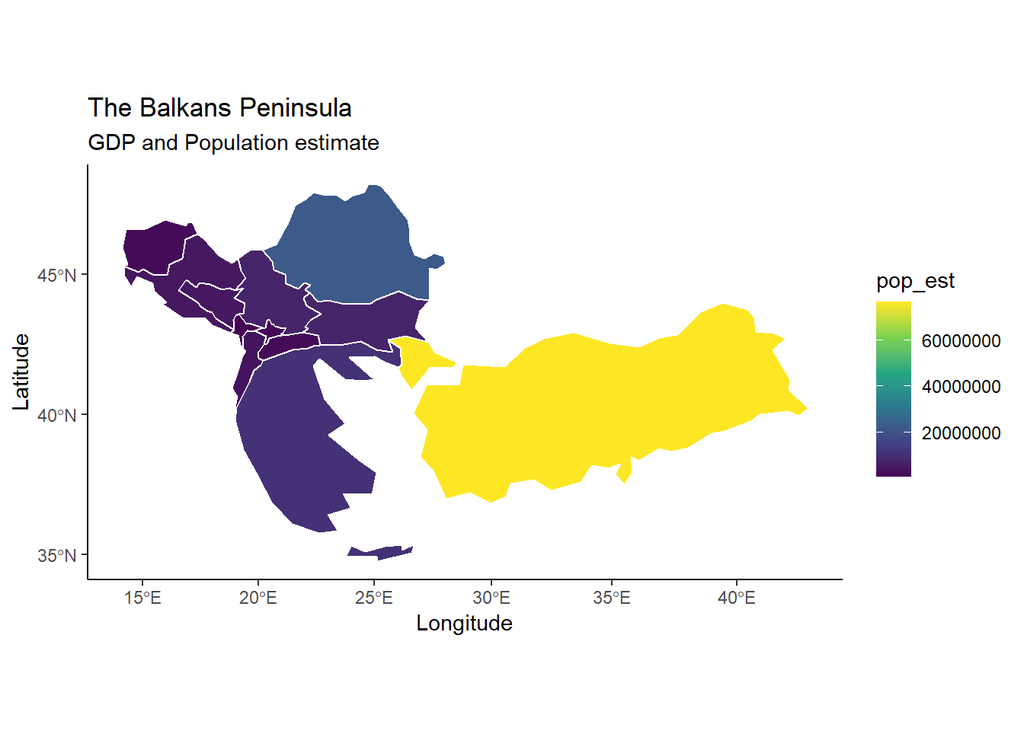

```r
options(scipen = 999)
balkans_cartogram_cont <- balkans_transformed %>%
 cartogram_cont("gdp_md_est")
ggplot(balkans_cartogram_cont, aes(fill = pop_est)) +
  geom_sf( color = "white") +
  xlab("Longitude") + ylab("Latitude") +
    ggtitle("The Balkans Peninsula", subtitle = paste0("GDP and Population estimate")) +
  scale_fill_viridis_c() +
  theme_classic()
```

### Non-continuous cartogram

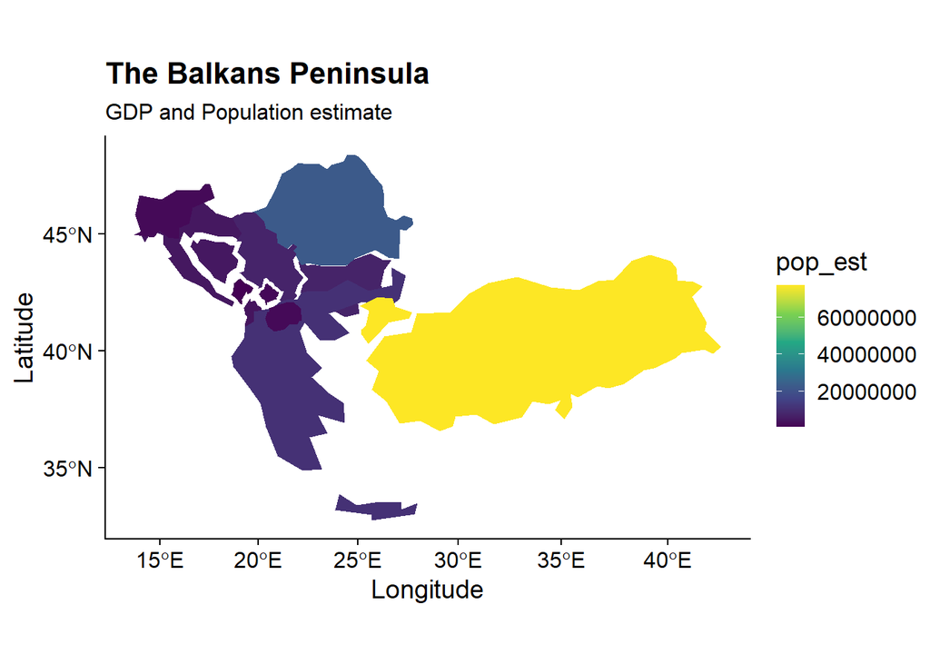

```r
balkans_cartogram_ncont <- balkans_transformed %>%
  cartogram_ncont("gdp_md_est")
ggplot(balkans_cartogram_ncont, aes(fill = pop_est)) +
  geom_sf(color = NA) +
  xlab("Longitude") + ylab("Latitude") +
    ggtitle("The Balkans Peninsula", subtitle = paste0("GDP and Population estimate")) +
  scale_fill_viridis_c() +
  theme_cowplot() +
  theme(legend.background = element_blank())
```

### Dorling cartogram

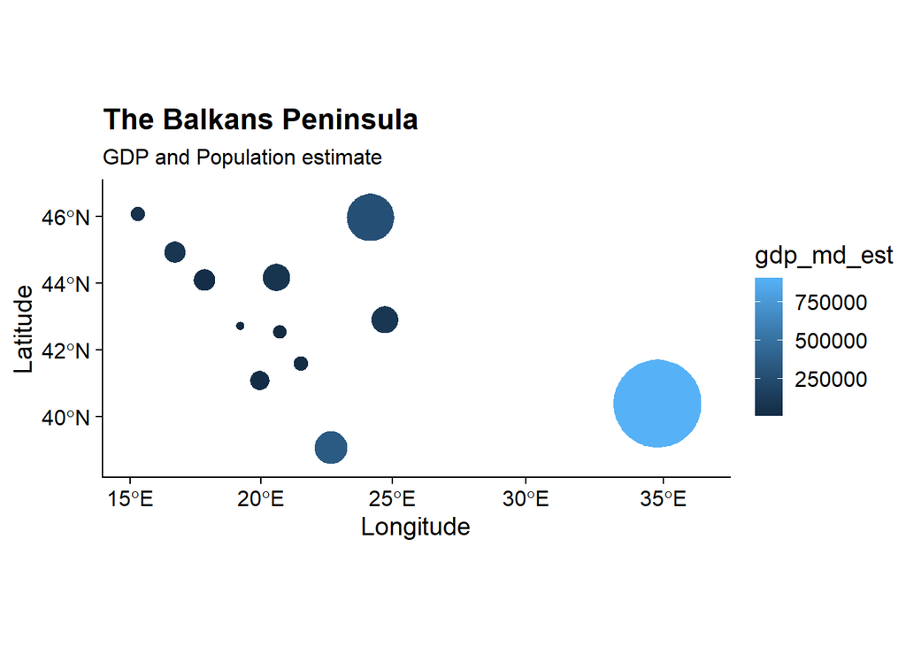

```r
balkans_cartogram_dorling <- balkans_transformed %>%
  cartogram_dorling("pop_est")
ggplot(balkans_cartogram_dorling, aes(fill = gdp_md_est)) +
  geom_sf(color = NA) +
    xlab("Longitude") + ylab("Latitude") +
    ggtitle("The Balkans Peninsula", subtitle = paste0("GDP and Population estimate")) +
  theme_cowplot() +
  theme(legend.background = element_blank())
```

## Proportional symbol map

```r
balkans_centeroids <- balkans_transformed %>%
  st_centroid()
```

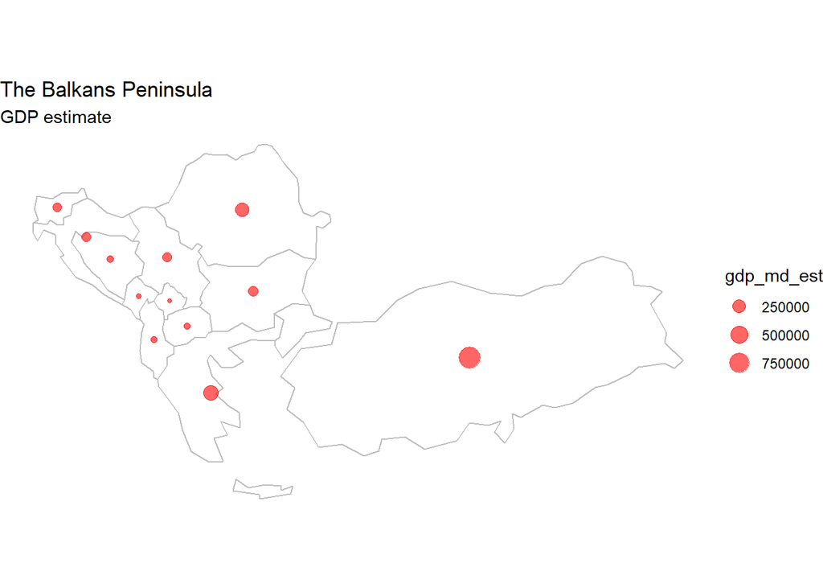

```r
ggplot(balkans_transformed) +
  geom_sf(fill = NA, color = "gray") +
  geom_sf(data = balkans_centeroids,
          aes(size = gdp_md_est),
          alpha = 0.6, color = "red") +
      xlab("Longitude") + ylab("Latitude") +
    ggtitle("The Balkans Peninsula", subtitle = paste0("GDP estimate")) +
  theme_void()
```